# Gradient Descent Simulation

## Implementing The 2D and 5D GD Algorithm using Matrix

```python
#Defining the function f(x) = a + bx^2. In matrix notation it is given by f(x) = x'Ax
def MDf(x,a):
    y = x.T @ a @ x
    return y

#Defining the gradient function g(x) of f(x) = derivative of f(x). In matrix notation it is given by f(x) = 2Ax
def MDgrad(x,a):
    #g = 2 * (a @ x)
    g = (a.T + a) @ x
    return g
```

```python
#This function will work for all multi-dimension matrix such as 2D and 5D
def calculateMDGD(x0, a, r, pri=False):
    print("\n\nWhen Learning rate (r) = ",r,":\n", sep="")
    iteration = 0            #empty list to count the umber of iterations
    stoppingCriteriaCtr = 0  #Stopping Criteria Counter; When its value becomes 5, the algorithm will stop
    fX = []                  #empty list to store the values of f(x)
    gX = []                  #empty list to store the values of g(x) or the gradient function
    X0 = []                  #empty list to store the values of x0
    X1 = []                  #empty list to store the values of x1
    i  = []                  #empty list to store the values of iterations

    while stoppingCriteriaCtr <=10:
        fX.append(MDf(x0,a)) #Calculating the value of f(x)

        gradX = MDgrad(x0,a) #Calculating and storing the value of g(x)
        gX.append(gradX)

        x1 = x0-r*gradX  #Calculating the value of x1 (gradient descent (denoted by -ve sign))
        X1.append(x1)     #Storing the value of x01
        X0.append(x0)     #Storing the value of x0

        iteration = iteration + 1 #Calculating & storing the value of iteration number
        i.append(iteration)

        #In the following code, if the values of x1 and x0 are same (accuracy until the 7th decimal digit),
        #for 10 times in a row, then we can assume that we have reached the lowest value of x0 and the loop
        #must halt. If the number of iterations reach 10,000 before x1 and x0 are equal, then the loop must stop.

        tempx0 = np.around(x0,7)
        tempx1 = np.around(x1,7)
        if(all(tempx0==tempx1)==True):
            stoppingCriteriaCtr = stoppingCriteriaCtr+1
        elif(iteration==10000):
            stoppingCriteriaCtr=10
        else:
            stoppingCriteriaCtr=0
        #stoppingCriteriaCtr = stoppingCriteriaCtr+1
        x0 = x1

    #Collating our findings into a data frame
    if(pri==True):
        data = {"Iteration #":i, "Function f(x)":fX, "Gradient Function g(x)":gX, "Input Value (x0)":X0}
        dataDF = pd.DataFrame(data)
        print("\n\n",dataDF)

    print("Point of convergence: \n",x1, sep="")
    print("Local minima is achieved in ",iteration, " iterations.", sep="")

    X=np.asarray(X1)[:,0]
    Y=np.asarray(X1)[:,1]
    return(X,Y)
```

```python
#This function plots the contour plot of the gradient descent of the function defined above
#This function also plots the various values of x0 (both X and Y values) that it takes over all the iterations
#This function takes in a "window parameter" that adjusts the size of the plot as required
#This function also takes in the matrix a as a parameter that is later passed to f(x,a)
def plotContour(X,Y,a,windowParameter):
    ex1 = np.linspace(-windowParameter, windowParameter, 30) #Equally spaced 30 numbers
    ex2 = np.linspace(-windowParameter, windowParameter, 30) #Equally spaced 30 numbers
    (xm1, xm2) = np.meshgrid(ex1, ex2)
    # check what is the shape of xm1, xm2!
    #x1 = xm1.ravel() ravel function just flattens the array. This is useless here.
    # check, what exactly does 'ravel' do
    #x2 = xm2.ravel()
    z = np.empty_like(xm1)
    ## now just do a nested loop
    for i in range(30):
        for j in range(30):
            x = np.array([[xm1[i,j]], [xm2[i,j]]])
            #Here the correct format is 2x1 array. MDf(x,a), the dimension of x must be 2x1.
            z[i,j] = MDf(x,a)
    ## and contour plot it:
    fig = plt.figure(figsize=(5,5))
    ax = fig.add_subplot(111)
    ax.set_aspect('equal')
    # use equal aspect ratio: the gradient will show up correctly
    cs = ax.contour(ex1, ex2, z)
    # create the contour plot
    ax.clabel(cs, inline=1, fontsize=10)
    # you may want to label the contour, for your reference and debugging.
    plt.scatter(X,Y, c='red', s=5)
    plt.plot(X,Y, c='red')
    plt.show()
```

```
When X0 =
 [[ 2]
 [-3]]



When Learning rate (r) = 0.1:

Point of convergence:
[[ 2.42833612e-09]
 [-3.64250417e-09]]
Local minima is achieved in 92 iterations.
```

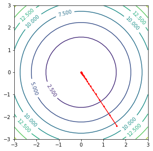

```
When Learning rate (r) = 0.01:

Point of convergence:
[[ 1.83798812e-07]
 [-2.75698219e-07]]
Local minima is achieved in 802 iterations.
```

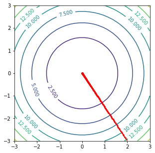

```
When Learning rate (r) = 0.001:

Point of convergence:
[[ 2.77087663e-06]
 [-4.15631495e-06]]
Local minima is achieved in 6738 iterations.
```

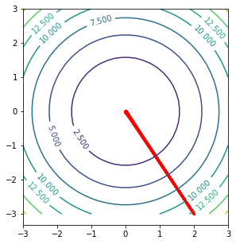

```python
x = np.array([[2],[-3]])
a = np.array([[1,0],[0,1]])

print("\nWhen X0 = \n", x,"\n")

X,Y = calculateMDGD(x, a, 0.1)
plotContour(X,Y,a,3)

X,Y = calculateMDGD(x, a, 0.01)
plotContour(X,Y,a,3)

X,Y = calculateMDGD(x, a, 0.001)
plotContour(X,Y,a,3)
```

From the above analyses we can ascertain that:

- As the learning rate (r) decreases, the number of iterations to achieve the local minima/convergence increases.

```python
A = np.arange(1,26).reshape(5,5)
A = 0.5 * (A.T + A) + 10*np.identity(5)
x0 = np.array([[10],[20],[30],[40],[50]])
print("\nWhen X0 = \n", x0,"\n")

#X,Y = calculate5DGD(x0, A, 0.1) #This gives a runtime error #
lr = [0.01, 0.001, 0.0001]
for i in lr:
    X,Y = calculateMDGD(x0, A, i)
```

```
When X0 =
 [[10]
 [20]
 [30]
 [40]
 [50]]



When Learning rate (r) = 0.01:

Point of convergence:
[[-2.11338597e-08]
 [-1.24033700e-08]
 [-3.67288022e-09]
 [ 5.05760954e-09]
 [ 1.37880993e-08]]
Local minima is achieved in 258 iterations.


When Learning rate (r) = 0.001:

Point of convergence:
[[-7.74538797e-07]
 [-4.54573437e-07]
 [-1.34608078e-07]
 [ 1.85357282e-07]
 [ 5.05322642e-07]]
Local minima is achieved in 2184 iterations.


When Learning rate (r) = 0.0001:

Point of convergence:
[[-1.08581834e-05]
 [-6.37262039e-06]
 [-1.88705742e-06]
 [ 2.59850555e-06]
 [ 7.08406851e-06]]
Local minima is achieved in 18336 iterations.
```

## Condition Numbers

```python
A = np.array([[1,1],[1,1]])
print("\nDeterminant:",np.linalg.det(A)) #Calculating the determinant
print("\nCondition Number:",np.linalg.cond(A))
```

```
Determinant: 0.0

Condition Number: 5.961777047638983e+16
```

- Since the determinant of the above matrix is 0, hence it is singular
- SInce the matrix is singular, its condition number is infinite.

```python
def conditionNumbers(alpha,A):
    c = A + alpha*np.eye(2)
    ev = np.linalg.eig(c) #eigen value
    cn = np.linalg.cond(c) #condition numbers
    print("\n\n\t\tWhen alpha =",alpha)
    print("\nThe unit matrix becomes:\n",c)
    print("\nEigen Values:\n",ev)
    print("\nCondition Number:",cn)
    print("\nDeterminant:",np.linalg.det(c))
```

```python
cn = [0.01,1,100]
for i in cn:
    conditionNumbers(i,A)
```

```
		When alpha = 0.01

The unit matrix becomes:
 [[1.01 1.  ]
 [1.   1.01]]

Eigen Values:
 (array([2.01, 0.01]), array([[ 0.70710678, -0.70710678],
       [ 0.70710678,  0.70710678]]))

Condition Number: 201.00000000000261

Determinant: 0.020100000000000017


		When alpha = 1

The unit matrix becomes:
 [[2. 1.]
 [1. 2.]]

Eigen Values:
 (array([3., 1.]), array([[ 0.70710678, -0.70710678],
       [ 0.70710678,  0.70710678]]))

Condition Number: 2.999999999999999

Determinant: 2.9999999999999996


		When alpha = 100

The unit matrix becomes:
 [[101.   1.]
 [  1. 101.]]

Eigen Values:
 (array([102., 100.]), array([[ 0.70710678, -0.70710678],
       [ 0.70710678,  0.70710678]]))

Condition Number: 1.0199999999999998

Determinant: 10200.00000000001
```

- Condition number of a matrix A is defined as ||A|| * ||A^-1|| where ||A|| is the norm of matrix A
- If a matrix is singular, then its condition number is infinite.
- The condition number of the matrix measures the ratio of the maximum relative stretching to the maximum relative shrinking that matrix does to any non zero vectors.
- Another way to say that the condition number of a matrix measures the amount of distortion of the unit sphere (in the corresponding vector norm) under the transformation by the matrix. The larger the condition number, the more distorted (relatively long and thin) the unit sphere becomes when transformed by the matrix.
- Source: http://www.cse.iitd.ernet.in/~dheerajb/CS210_lect07.pdf

```python
def difAlpha(alpha,A):
    c = A + alpha*np.eye(2)
    return c
```

```
When Learning rate (r) = 0.1:

Point of convergence:
[ 4.35156521e-06 -4.35156521e-06]
Local minima is achieved in 6624 iterations.


		When alpha = 0.01

The unit matrix becomes:
 [[1.02 1.  ]
 [1.   1.02]]

Eigen Values:
 (array([2.02, 0.02]), array([[ 0.70710678, -0.70710678],
       [ 0.70710678,  0.70710678]]))

Condition Number: 100.99999999999996

Determinant: 0.04040000000000007
```

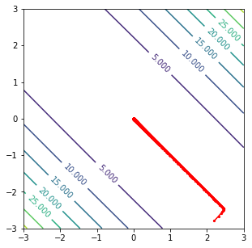

```
When Learning rate (r) = 0.01:

Point of convergence:
[ 4.47507491e-05 -4.47507491e-05]
Local minima is achieved in 54648 iterations.


		When alpha = 0.01

The unit matrix becomes:
 [[1.02 1.  ]
 [1.   1.02]]

Eigen Values:
 (array([2.02, 0.02]), array([[ 0.70710678, -0.70710678],
       [ 0.70710678,  0.70710678]]))

Condition Number: 100.99999999999996

Determinant: 0.04040000000000007
```

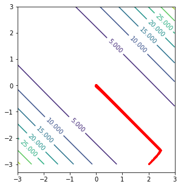

```
When Learning rate (r) = 0.001:

Point of convergence:
[ 0.00045215 -0.00045215]
Local minima is achieved in 430885 iterations.


		When alpha = 0.01

The unit matrix becomes:
 [[1.02 1.  ]
 [1.   1.02]]

Eigen Values:
 (array([2.02, 0.02]), array([[ 0.70710678, -0.70710678],
       [ 0.70710678,  0.70710678]]))

Condition Number: 100.99999999999996

Determinant: 0.04040000000000007
```

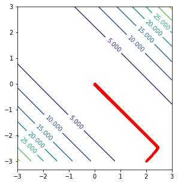

```
When Learning rate (r) = 0.0001:

Point of convergence:
[ 0.00453885 -0.00453885]
Local minima is achieved in 3155683 iterations.


		When alpha = 0.01

The unit matrix becomes:
 [[1.02 1.  ]
 [1.   1.02]]

Eigen Values:
 (array([2.02, 0.02]), array([[ 0.70710678, -0.70710678],
       [ 0.70710678,  0.70710678]]))

Condition Number: 100.99999999999996

Determinant: 0.04040000000000007
```

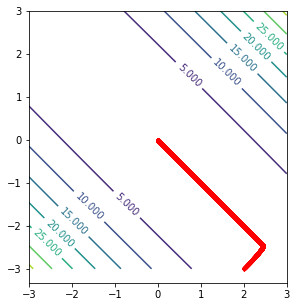

```
When Learning rate (r) = 0.1:

Point of convergence:
[ 3.79427518e-09 -3.79427518e-09]
Local minima is achieved in 91 iterations.


		When alpha = 1

The unit matrix becomes:
 [[3. 1.]
 [1. 3.]]

Eigen Values:
 (array([4., 2.]), array([[ 0.70710678, -0.70710678],
       [ 0.70710678,  0.70710678]]))

Condition Number: 2.0000000000000004

Determinant: 8.000000000000002
```

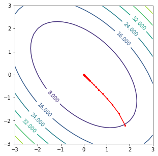

```
When Learning rate (r) = 0.01:

Point of convergence:
[ 3.583266e-07 -3.583266e-07]
Local minima is achieved in 780 iterations.


		When alpha = 1

The unit matrix becomes:
 [[3. 1.]
 [1. 3.]]

Eigen Values:
 (array([4., 2.]), array([[ 0.70710678, -0.70710678],
       [ 0.70710678,  0.70710678]]))

Condition Number: 2.0000000000000004

Determinant: 8.000000000000002
```

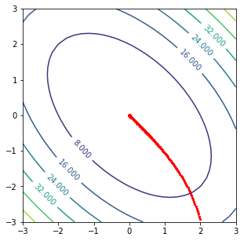

```
When Learning rate (r) = 0.001:

Point of convergence:
[ 4.35156521e-06 -4.35156521e-06]
Local minima is achieved in 6624 iterations.


		When alpha = 1

The unit matrix becomes:
 [[3. 1.]
 [1. 3.]]

Eigen Values:
 (array([4., 2.]), array([[ 0.70710678, -0.70710678],
       [ 0.70710678,  0.70710678]]))

Condition Number: 2.0000000000000004

Determinant: 8.000000000000002
```

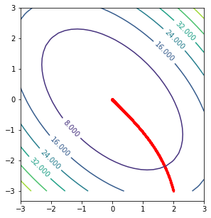

```
When Learning rate (r) = 0.0001:

Point of convergence:
[ 4.47507491e-05 -4.47507491e-05]
Local minima is achieved in 54648 iterations.


		When alpha = 1

The unit matrix becomes:
 [[3. 1.]
 [1. 3.]]

Eigen Values:
 (array([4., 2.]), array([[ 0.70710678, -0.70710678],
       [ 0.70710678,  0.70710678]]))

Condition Number: 2.0000000000000004

Determinant: 8.000000000000002
```

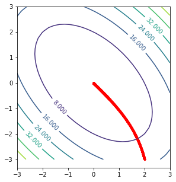

```
When Learning rate (r) = 0.001:

Point of convergence:
[ 2.65261987e-09 -3.41822041e-09]
Local minima is achieved in 92 iterations.


		When alpha = 100

The unit matrix becomes:
 [[201.   1.]
 [  1. 201.]]

Eigen Values:
 (array([202., 200.]), array([[ 0.70710678, -0.70710678],
       [ 0.70710678,  0.70710678]]))

Condition Number: 1.01

Determinant: 40400.0
```

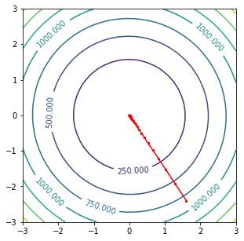

```
When Learning rate (r) = 0.0001:

Point of convergence:
[ 2.65953719e-07 -3.56191222e-07]
Local minima is achieved in 787 iterations.


		When alpha = 100

The unit matrix becomes:
 [[201.   1.]
 [  1. 201.]]

Eigen Values:
 (array([202., 200.]), array([[ 0.70710678, -0.70710678],
       [ 0.70710678,  0.70710678]]))

Condition Number: 1.01

Determinant: 40400.0
```

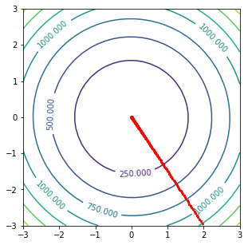

```python
A = np.array([[1,1],[1,1]])
x0 = np.array([2,-3])

alpha = [0.01,1,100]
lr = [0.1, 0.01, 0.001, 0.0001]

for i in alpha:
    a = difAlpha(i,A)
    for j in lr:
        if(i==100 and (j==0.1 or j==0.01)):
            continue
            #We are excluding the case where alpha = 100 and learning rate is either 0.1 or 0.01
            #because in these cases we are unable to reach the minima as we overshoot it
        else:
            X,Y = calculateMDGD(x0, a, j)
            conditionNumbers(i,a)
            plotContour(X,Y,a,3)
```

- For constant alpha, the number of iterations/time taken for convergence increase with a decrease in learning rate
- For constant alpha, the condition number remains constant when the learning rate decreses
- For constant learning rate, the number of iterations/time taken for convergence decrease with a increase in alpha
- For constant learning rate, the condition number decreases drastically with a increase in alpha